# Model creation and Evaluation

Sep 24, 2019

## Summary

The purpose of this application is for the user to easily select the variables to use in a linear model and then simply predict the mpg for a new car. While looking at a new car, we sometimes don't have all the information avaiable to make a perfect prediction of the mpg, so we'll use as many or as few variables that we have.

The linear model uses the selected variables to predict the mpg of a new car based on the inputs provided.

The regressions use the mtcars information provided in r

## Preliminary Look

An initial look at the data shows there are many variables that correlate with the mpg of a car

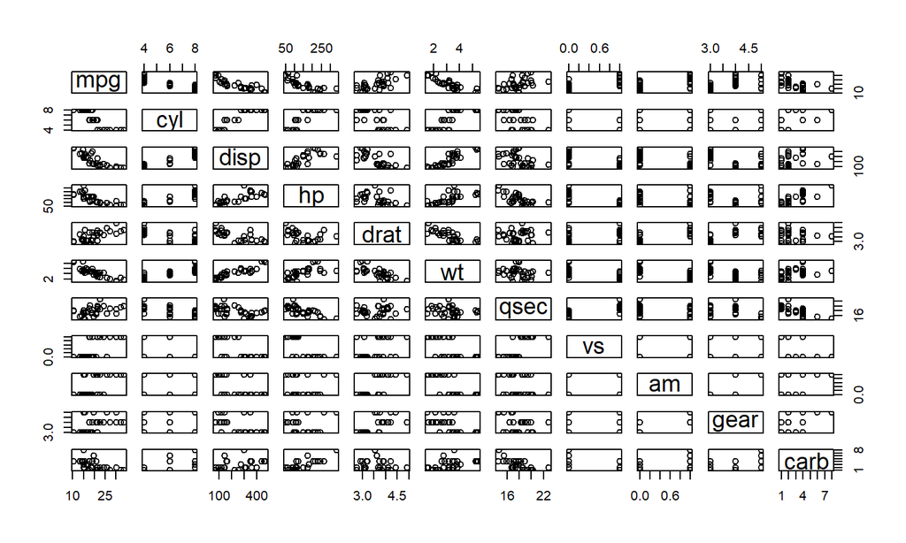

## Basic Summary

These variables include: 1. Weight (wt) 2. Engine Displacement (disp) 3. Number of Cylinders (cyl) 4. Transmissions Type (am)

## The Final Model

The final Model:

```r
  lm(mpg~(wt+disp+cyl)*am, data=mtcars)
```

```
##
## Call:
## lm(formula = mpg ~ (wt + disp + cyl) * am, data = mtcars)
##
## Residuals:
##     Min      1Q  Median      3Q     Max
## -2.7655 -1.6196 -0.6147  1.5123  5.3774
##
## Coefficients:
##              Estimate Std. Error t value Pr(>|t|)
## (Intercept) 35.188714   4.249995   8.280 1.71e-08 ***
## wt          -2.412871   1.276573  -1.890   0.0709 .
## disp         0.002604   0.012857   0.203   0.8412
## cyl         -1.396746   0.659940  -2.116   0.0449 *
## am           8.206076   5.974281   1.374   0.1823
## wt:am       -4.636474   2.460788  -1.884   0.0717 .
## disp:am     -0.023464   0.026662  -0.880   0.3876
## cyl:am       1.591258   1.524009   1.044   0.3068
## ---
## Signif. codes:  0 '***' 0.001 '**' 0.01 '*' 0.05 '.' 0.1 ' ' 1
##
## Residual standard error: 2.347 on 24 degrees of freedom
## Multiple R-squared:  0.8826, Adjusted R-squared:  0.8483
## F-statistic: 25.76 on 7 and 24 DF,  p-value: 1.088e-09
```